# PEP Access

Malavika Rajeev

6/25/2018

- 16 months of data on reported animal bites from the Moramanga District in Madagascar (can calculate the annual # of bites per 100k persons per commune)
- Commune level average travel time to the closest CTAR (where PEP is available).
- Human population per commune

## Rationale

Access to PEP is geographically limited in Madagascar, with PEP available in only 31 clinics across the country. Therefore the burden of human rabies deaths is likely heterogeneous spatially.

Standard decision tree models using overall reported bites would estimate rabies exposure incidence ($R$) as:
$$R = \frac{B\times p_{rabid}}{p_{report}}$$

where *B* is the total reported bites, *p_rabid* is the probability that a reported animal bite is a genuine rabies exposure, *p_report* is the probability that a rabies exposure is reported.

We generate high and low estimates of expected rabies incidence ($R$) using estimates from a recent modeling study that generated incidence of human exposures per 100,000 dogs in a no-vaccination scenario and given high and low estimates of human:dog ratios. We can do this in Madagascar because there’s no vacc going on!

Applying this framework to our data on reported bites in the Moramanga District, we see that estimated rabies incidence exceeds expected incidence in areas with high incidence of reported bites and is lower than expected for areas with little data/low incidence of reported bites (Figure 1).

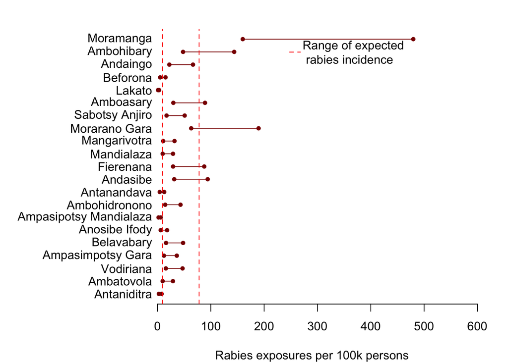

```r
## adding in expected exposures annually
# rabies incidence per 100kdogs/# of human exps per rabid dog/human:dog ratio = inc per 100k persons
exps.per100k.high <- 1000*0.39/5
exps.per100k.low <- 600*0.39/25

ordered.bites <- moramanga$monthly.incidence[order(moramanga$commune.midpops)]*12
par(mar = c(4, 10, 2, 2))
plot(ordered.bites*0.6/0.85, 1:length(monthly.bites), bty = "l", pch = 20, col = "darkred",
     xlab = "Rabies exposures per 100k persons", ylab = "", axes = FALSE,
     xlim = c(0, max(ordered.bites*0.6/0.85)+100))
axis(1)
text(moramanga$commune[order(moramanga$commune.midpops)], y = 1:length(monthly.bites), x = -10, adj = 1, xpd = TRUE)
points(ordered.bites*0.2/0.85, 1:length(monthly.bites),
       pch = 20, col = "darkred")
segments(y0 = 1:length(monthly.bites), x0 = ordered.bites*0.2/0.85,
         y1 = 1:length(monthly.bites),
         x1 = ordered.bites*0.6/0.85, col = "darkred")
abline(v = c(exps.per100k.high, exps.per100k.low), col = c("red", "red"), lty = 2)
legend("topleft", "Range of expected \n rabies incidence", col = "red", lty = 2, bty = "n",
       inset = c(0.4, 0), xpd = TRUE, x.intersp = 0.2, seg.len = 1)
```

## Empirical estimates of p_report for each location across a range of scenarios

We can calculate p_report empirically assuming incidence and p_rabid is uniform:
$$p_{report} = \frac{B\times p_{rabid}}{R}$$

We constrain $p_{rabid}$ so that p_report cannot exceed 1:
$$p_{rabid}=
\begin{cases}
1, & \text{if}\ \frac{R}{B} > 1 \\
\frac{R}{B}, & \text{otherwise}
\end{cases}$$
which would give us the highest estimates of reporting for a given incidence level (that is assuming that the maximum # of bites are reported).

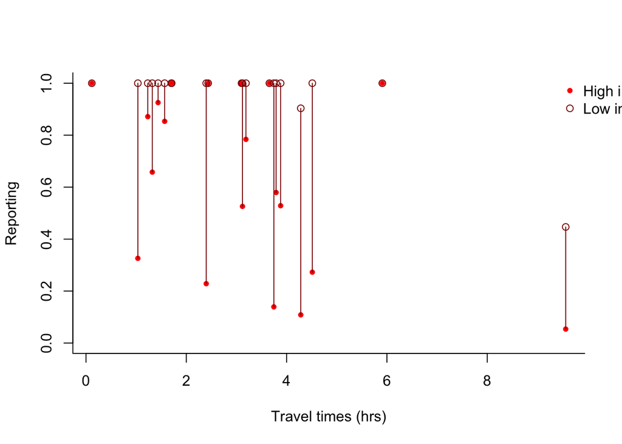

```r
p_rabid_high <- exps.per100k.high/(moramanga$monthly.incidence*12)
p_rabid_high[p_rabid_high >= 1] <- 1
p_rabid_low <- exps.per100k.low/(moramanga$monthly.incidence*12)
p_rabid_low[p_rabid_low >= 1] <-1

## p_report
plot(moramanga$study.area.accessibility/60,
     moramanga$monthly.incidence*12*p_rabid_high/exps.per100k.high, ylim = c(0, 1),
     col = "red", pch = 20, bty = "l", xlab = "Travel times (hrs)", ylab = "Reporting")
points(moramanga$study.area.accessibility/60,
     moramanga$monthly.incidence*12*p_rabid_low/exps.per100k.low,
     col = "darkred")
segments(x0 = moramanga$study.area.accessibility/60, y0 = moramanga$monthly.incidence*12*p_rabid_low/exps.per100k.low,
         x1 = moramanga$study.area.accessibility/60,
         y1 = moramanga$monthly.incidence*12*p_rabid_high/exps.per100k.high, col = "darkred")
legend("topright", c("High incidence", "Low incidence"), col = c("Red", "darkred"), pch = c(20, 1),
       bty = "n", inset = c(-0.2, 0), xpd = TRUE)
```

## Models of reporting by travel time to clinic

To generate more probable estimates of rabies burden given what we know about access to PEP in Maadagascar, we use assumptions of rabies exposure incidence and our data on reported bites to estimate $p_{report}$ based on our original decision tree: $B = \frac{R\times p_{report}}{p_{rabid}}$

```r
### data
bites <- round(moramanga$monthly.bites*12)
ttimes <- moramanga$study.area.accessibility/60
pop <- moramanga$commune.midpops
nlocs <- length(bites)
expected.mean <- exps.per100k.high/2*moramanga$commune.midpops/1e5

## model
tt.model <- "model {
# reported bites
for (j in 1:nlocs){
# Number of bites
bites[j] ~ dpois(expected.mean[j]*rho[j]/p_rabid[j])
}

# spatial effects
for (g in 1:nlocs){
# Spatial random effect
loc_eff[g] ~ dnorm(0, tau_loc)

# Reporting in place g
logit(rho[g]) <- B_tt*(1/ttimes[g]) + loc_eff[g]

# Background avg in place g
p_rabid[g] <- 1/(1 + sqrt(expected.mean[g]*rho[g])*B_norm)
}

tau_loc <- 1/sd

# priors
B_tt ~ dnorm(0, 0.1)
sd ~ dnorm(0, 0.1)
B_norm ~ dnorm(0.1, 0.1)
}"


data <- list (bites = bites,
              expected.mean = expected.mean,
              ttimes = ttimes, nlocs = nlocs)

inits <- list(B_tt = rnorm(1, 0, 1e-6), sd = 1,
              B_norm = rnorm(1, 0, 1e-6))

jags_mod <- jags.model(textConnection(tt.model), data = data, inits = inits, n.chains = 5,
                       n.adapt = 1000)
params <- c("B_tt", "sd", "B_norm")

samps <- coda.samples(jags_mod, params, n.iter = 10000)
burn.in <- 5000
check <- summary(window(samps, start = burn.in))
check
```

```
##
## Iterations = 5000:11000
## Thinning interval = 1
## Number of chains = 5
## Sample size per chain = 6001
##
## 1. Empirical mean and standard deviation for each variable,
##    plus standard error of the mean:
##
##          Mean     SD Naive SE Time-series SE
## B_norm 3.8019 0.3185 0.001839       0.007631
## B_tt   0.4733 0.3171 0.001831       0.008201
## sd     2.6170 0.9376 0.005413       0.012226
##
## 2. Quantiles for each variable:
##
##            2.5%    25%    50%    75% 97.5%
## B_norm  3.30277 3.5993 3.7701 3.9590 4.485
## B_tt   -0.04711 0.2618 0.4351 0.6403 1.215
## sd      1.24950 1.9386 2.4631 3.1263 4.847
```

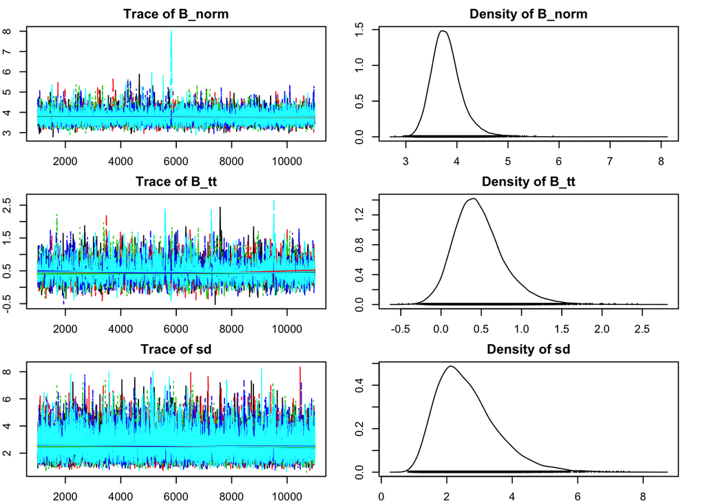

```r
par(mar = c(2, 2, 2, 2))
plot(samps)
```

```r
# gelman.plot(samps)
gelman.diag(samps)
```

```
## Potential scale reduction factors:
##
##        Point est. Upper C.I.
## B_norm       1.01       1.02
## B_tt         1.00       1.00
## sd           1.00       1.00
##
## Multivariate psrf
##
## 1
```

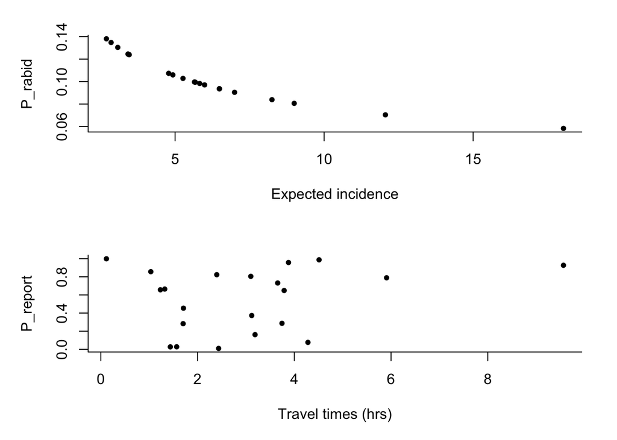

```r
## parameter estimates
par(mfrow = c(2, 1), mar = c(5, 5, 2,  2))
plot(expected.mean, 1/(1 + sqrt(expected.mean)*check$statistics[,"Mean"]["B_norm"]), bty = "l",
     pch = 20, xlab = "Expected incidence", ylab = "P_rabid")
plot(ttimes, plogis(check$statistics[,"Mean"]["B_tt"]*(1/ttimes)
                    + rnorm(length(ttimes), mean = 0, sd = check$statistics[,"Mean"]["sd"])),
     bty = "l", pch = 20, xlab = "Travel times (hrs)", ylab = "P_report")
```

```r
## mean and confidence interval
sims = 1000
bites.sim.high <- matrix(0, nrow = sims, ncol = length(bites))
for (i in 1:sims){
  rho <- plogis(check$statistics[,"Mean"]["B_tt"]*(1/ttimes)
                    + rnorm(length(ttimes), mean = 0, sd = check$statistics[,"Mean"]["sd"]))
  p_rabid <- 1/(1 + sqrt(expected.mean*rho)*check$statistics[,"Mean"]["B_norm"])
  bites.sim.high[i, ] <- rpois(length(p_rabid), expected.mean*rho/p_rabid)
}
rankCI <- function(x){
  upper <- x[order(x)][0.95*length(x)]
  lower <- x[order(x)][0.05*length(x)]
  return(c(lower, upper))
}

upper.CI.high <- apply(bites.sim.high, 2, rankCI)[2,]
lower.CI.high <- apply(bites.sim.high, 2, rankCI)[1,]
```

```r
### data
expected.mean <- exps.per100k.low/2*moramanga$commune.midpops/1e5

data <- list (bites = bites,
              expected.mean = expected.mean,
              ttimes = ttimes, nlocs = nlocs)

inits <- list(B_tt = rnorm(1, 0, 1e-6), sd = 1,
              B_norm = rnorm(1, 0, 1e-6))

jags_mod <- jags.model(textConnection(tt.model), data = data, inits = inits, n.chains = 5,
                       n.adapt = 1000)
params <- c("B_tt", "sd", "B_norm")

samps <- coda.samples(jags_mod, params, n.iter = 10000)
burn.in <- 5000
check <- summary(window(samps, start = burn.in))
check
```

```
##
## Iterations = 5000:11000
## Thinning interval = 1
## Number of chains = 5
## Sample size per chain = 6001
##
## 1. Empirical mean and standard deviation for each variable,
##    plus standard error of the mean:
##
##          Mean     SD Naive SE Time-series SE
## B_norm 42.210 1.8356 0.010597        0.01780
## B_tt    1.392 0.5756 0.003323        0.01144
## sd      2.460 1.0737 0.006199        0.01714
##
## 2. Quantiles for each variable:
##
##           2.5%     25%    50%    75%  97.5%
## B_norm 38.6787 40.9523 42.183 43.429 45.851
## B_tt    0.5547  0.9745  1.293  1.714  2.771
## sd      0.9529  1.6869  2.263  3.019  5.084
```

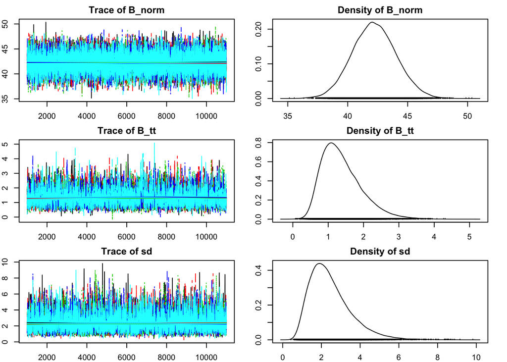

```r
par(mar = c(2, 2, 2, 2))
plot(samps)
```

```r
# gelman.plot(samps)
gelman.diag(samps)
```

```
## Potential scale reduction factors:
##
##        Point est. Upper C.I.
## B_norm          1          1
## B_tt            1          1
## sd              1          1
##
## Multivariate psrf
##
## 1
```

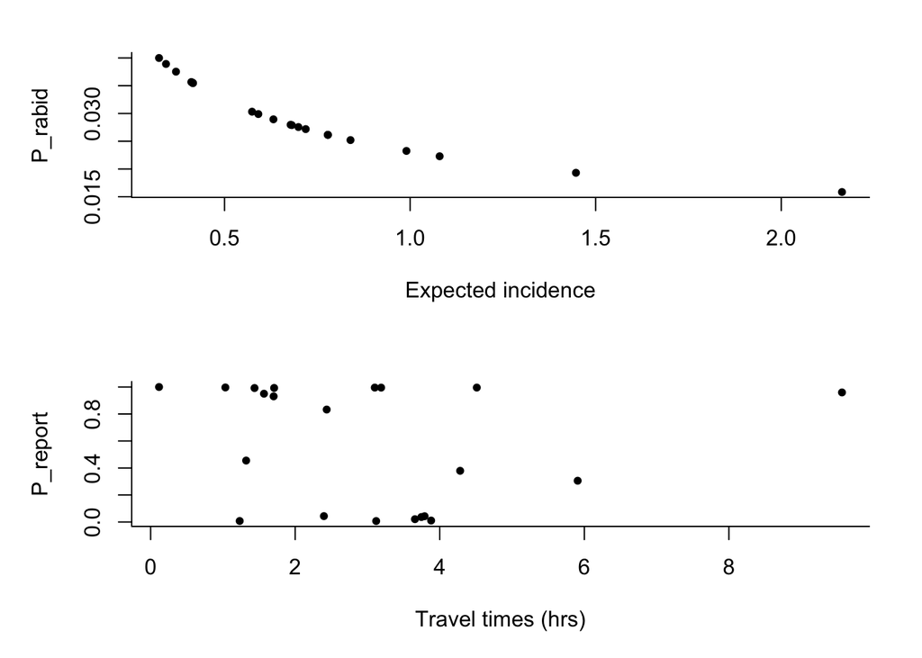

```r
## parameter estimates
par(mfrow = c(2, 1), mar = c(5, 5, 2,  2))
plot(expected.mean, 1/(1 + sqrt(expected.mean)*check$statistics[,"Mean"]["B_norm"]), bty = "l",
     pch = 20, xlab = "Expected incidence", ylab = "P_rabid")
plot(ttimes, plogis(check$statistics[,"Mean"]["B_tt"]*(1/ttimes)
                    + rnorm(length(ttimes), mean = 0, sd = check$statistics[,"Mean"]["sd"])),
     bty = "l", pch = 20, xlab = "Travel times (hrs)", ylab = "P_report")
```

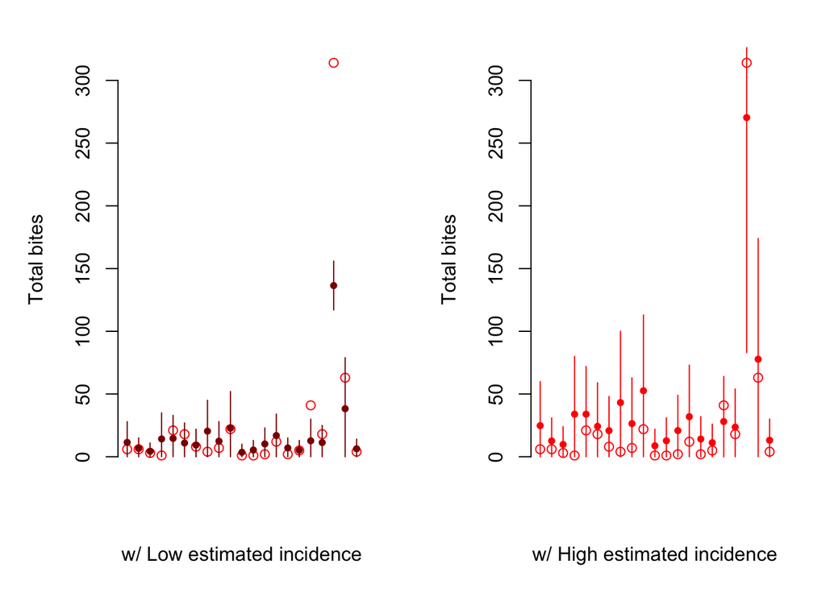

```r
## mean and confidence interval
sims = 1000
bites.sim.low <- matrix(0, nrow = sims, ncol = length(bites))
for (i in 1:sims){
  rho <- plogis(check$statistics[,"Mean"]["B_tt"]*(1/ttimes)
                    + rnorm(length(ttimes), mean = 0, sd = check$statistics[,"Mean"]["sd"]))
  p_rabid <- 1/(1 + sqrt(expected.mean*rho)*check$statistics[,"Mean"]["B_norm"])
  bites.sim.low[i, ] <- rpois(length(p_rabid), expected.mean*rho/p_rabid)
}
rankCI <- function(x){
  upper <- x[order(x)][0.95*length(x)]
  lower <- x[order(x)][0.05*length(x)]
  return(c(lower, upper))
}

upper.CI.low <- apply(bites.sim.low, 2, rankCI)[2,]
lower.CI.low <- apply(bites.sim.low, 2, rankCI)[1,]

par(mfrow = c(1, 2))
plot(bites, pch = 1, col = "red", bty = "l", xlab = "w/ Low estimated incidence",
     ylab = "Total bites", axes = FALSE)
axis(2)
points(colMeans(bites.sim.low), col = "darkred", pch = 20)
segments(x0 = 1:length(bites), y0 = lower.CI.low, x1 = 1:length(bites),
         y1 = upper.CI.low, col = "darkred")

plot(bites, pch = 1, col = "red", bty = "l", xlab = "w/ High estimated incidence",
     ylab = "Total bites",axes = FALSE)
axis(2)
points(colMeans(bites.sim.high), col = "red", pch = 20)
segments(x0 = 1:length(bites), y0 = lower.CI.high, x1 = 1:length(bites),
         y1 = upper.CI.high, col = "red")
```

## Right now: generating the right functional forms of p_report and p_rabid

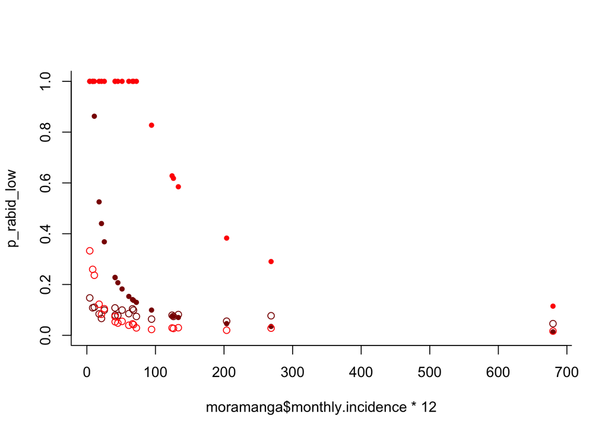

```r
## functional form of p_rabid
par(mfrow = c(1,1))
plot(moramanga$monthly.incidence*12, p_rabid_low, bty = "l", pch = 20, ylim = c(0,1), col = "darkred")
points(moramanga$monthly.incidence*12, p_rabid_high, pch = 20, col = "red")

points(moramanga$monthly.incidence*12,
       1/(1 + sqrt(exps.per100k.low*moramanga$commune.midpops/1e5)*
                     (moramanga$monthly.incidence*12*p_rabid_low/exps.per100k.low)*10), col = "darkred")

points(moramanga$monthly.incidence*12,
       1/(1 + sqrt(exps.per100k.high*moramanga$commune.midpops/1e5)*
                     (moramanga$monthly.incidence*12*p_rabid_high/exps.per100k.high)*10), col = "red")
```

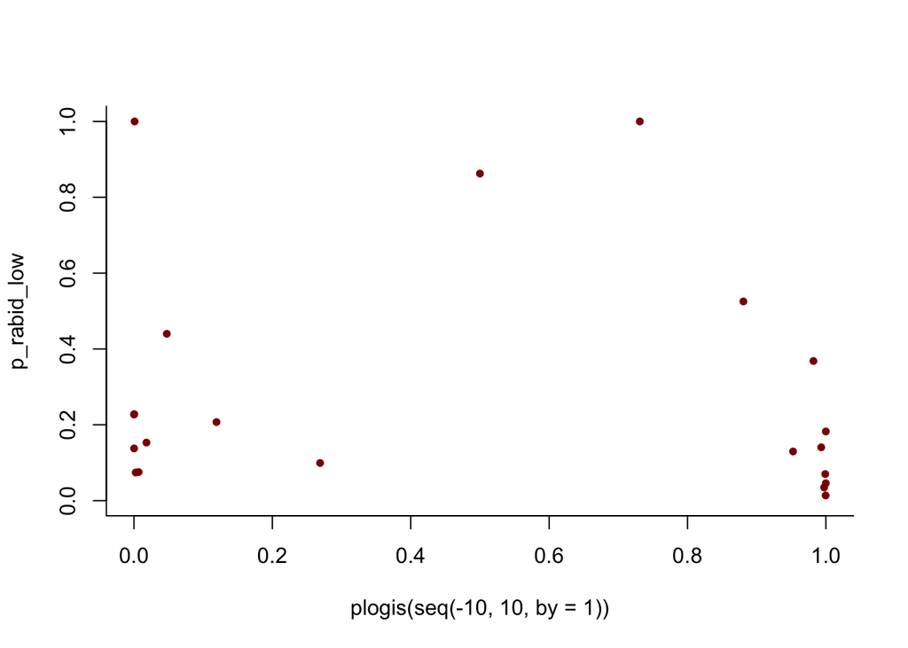

```r
par(mfrow = c(1,1))
plot(plogis(seq(-10, 10, by = 1)), p_rabid_low, bty = "l", pch = 20, ylim = c(0,1), col = "darkred")
points(moramanga$monthly.incidence*12, p_rabid_high, pch = 20, col = "red")

points(moramanga$monthly.incidence*12,
       1/(1 + sqrt(exps.per100k.low*moramanga$commune.midpops/1e5)*
                     (moramanga$monthly.incidence*12*p_rabid_low/exps.per100k.low)*10), col = "darkred")

points(moramanga$monthly.incidence*12,
       1/(1 + sqrt(exps.per100k.high*moramanga$commune.midpops/1e5)*
                     (moramanga$monthly.incidence*12*p_rabid_high/exps.per100k.high)*10), col = "red")
```

*Next step would be to clean the data from Madagascar and see if this works with the bigger data set*

*Question to be able to answer*: What would happen if we thought incidence scaled with population size in this range? Then generally we would see more conservative estimates of p_report overall.